# Defining a common peak set

1st August 2019

### Defining a common peak set

We have merged all 50 good-quality samples to do peak-calling. This protects us from data snooping when performing differential analyses later on.

However, there is a chance that we could be missing some stage-specific peaks because they get swamped by lack of signal in the other samples. And from the differential accessibility results we observed most, if not all, are changes in intensity, but not peaks present in some stages and absent in the rest.

Strong peaks shouldn’t be affected by merging all samples but, as a sanity check, we have repeated the peak calling on a per-stage basis. Now let’s see if we are missing anything substantial when all samples are combined.

#### Per-stage peak calls

We have variable numbers of replicates per stage that passed QC. This will result in variable power to call peaks

```r
meta <- read.table(paste0(dir, "ATAC-seq/data/metadata_ATACseq_GQ.tsv"), stringsAsFactors = FALSE, header = TRUE)
df <- as.data.frame(table(meta$stage))
colnames(df) <- c("stage", "numReplicates")
df
```

```
##   stage numReplicates
## 1     8             6
## 2    18            10
## 3    21             7
## 4    25            11
## 5    27             5
## 6    35            11
```

Indeed, there is a positive correlation between the number of replicates and the number of peaks called, with the stages with 10-11 samples calling around 90,000 peaks, whereas the stages with only 5-7 samples are more within the ~75,000 range.

```r
## all samples
peakSet <- readRDS(paste0(dir, "ATAC-seq/results/03_peakSet_full.Rds"))

## stage-specific
blacklist <- readRDS(paste0(dir, "ATAC-seq/data/mm10-blacklist.v2.Rds"))

stageSets <- list()
for(s in paste0("stage", c(8,18,21,25,27,35))){
  stageSets[[s]] <- read.table(paste0(dir, "ATAC-seq/peaks/",s,"_peaks.broadPeak"))
  stageSets[[s]] <- GRanges(stageSets[[s]]$V1, IRanges(stageSets[[s]]$V2, stageSets[[s]]$V3),
                            fc=stageSets[[s]]$V7, qval=stageSets[[s]]$V9)
  remove <- unique(queryHits(findOverlaps(stageSets[[s]], blacklist)))  # remove peaks in blacklisted regions
  stageSets[[s]] <- stageSets[[s]][-remove]
  names(stageSets[[s]]) <- paste0(seqnames(stageSets[[s]]), ":", start(stageSets[[s]]), "-", end(stageSets[[s]]))

}
df$numPeaks <- unlist(lapply(stageSets, length))
df
```

```
##   stage numReplicates numPeaks
## 1     8             6    71025
## 2    18            10    98553
## 3    21             7    77880
## 4    25            11    94356
## 5    27             5    68178
## 6    35            11    88487
```

When all samples are merged together we call 131743 peaks instead.

Reassuringly, over 93% of all the peaks called on a per-stage basis are also in the all-samples (merged) set, which means we haven’t missed much in the DA analyses.

```r
df$peaksInMerged <- c(length(unique(subjectHits(findOverlaps(peakSet, stageSets[["stage8"]])))),
                      length(unique(subjectHits(findOverlaps(peakSet, stageSets[["stage18"]])))),
                      length(unique(subjectHits(findOverlaps(peakSet, stageSets[["stage21"]])))),
                      length(unique(subjectHits(findOverlaps(peakSet, stageSets[["stage25"]])))),
                      length(unique(subjectHits(findOverlaps(peakSet, stageSets[["stage27"]])))),
                      length(unique(subjectHits(findOverlaps(peakSet, stageSets[["stage35"]])))))
df$peaksInMergedPct <- round(df$peaksInMerged/df$numPeaks*100,2)
df
```

```
##   stage numReplicates numPeaks peaksInMerged peaksInMergedPct
## 1     8             6    71025         68487            96.43
## 2    18            10    98553         95297            96.70
## 3    21             7    77880         76205            97.85
## 4    25            11    94356         92554            98.09
## 5    27             5    68178         66310            97.26
## 6    35            11    88487         82675            93.43
```

Still, there are about two thousand peaks present in the stage-specific calls, lost when all samples are merged together (more for stage35).

```r
stage8 <- stageSets[["stage8"]][stageSets[["stage8"]] %outside% peakSet]
stage18 <- stageSets[["stage18"]][stageSets[["stage18"]] %outside% peakSet]
stage21 <- stageSets[["stage21"]][stageSets[["stage21"]] %outside% peakSet]
stage25 <- stageSets[["stage25"]][stageSets[["stage25"]] %outside% peakSet]
stage27 <- stageSets[["stage27"]][stageSets[["stage27"]] %outside% peakSet]
stage35 <- stageSets[["stage35"]][stageSets[["stage35"]] %outside% peakSet]

data.frame(stage=paste0("stage", c(8,18,21,25,27,35)), missed=df$numPeaks-df$peaksInMerged)
```

```
##     stage missed
## 1  stage8   2538
## 2 stage18   3256
## 3 stage21   1675
## 4 stage25   1802
## 5 stage27   1868
## 6 stage35   5812
```

But most of these are specific to one stage only, with very small numbers present in the calls from different stages.

```r
overlap <- t(data.frame(
  stage8=c(length(unique(subjectHits(findOverlaps(stage8, stage18)))), length(unique(subjectHits(findOverlaps(stage8, stage21)))), length(unique(subjectHits(findOverlaps(stage8, stage25)))), length(unique(subjectHits(findOverlaps(stage8, stage27)))), length(unique(subjectHits(findOverlaps(stage8, stage35))))),
  stage18=c(NA, length(unique(subjectHits(findOverlaps(stage18, stage21)))), length(unique(subjectHits(findOverlaps(stage18, stage25)))), length(unique(subjectHits(findOverlaps(stage18, stage27)))), length(unique(subjectHits(findOverlaps(stage18, stage35))))),
  stage21=c(NA, NA, length(unique(subjectHits(findOverlaps(stage21, stage25)))), length(unique(subjectHits(findOverlaps(stage21, stage27)))), length(unique(subjectHits(findOverlaps(stage21, stage35))))),
  stage25=c(NA, NA, NA, length(unique(subjectHits(findOverlaps(stage25, stage27)))), length(unique(subjectHits(findOverlaps(stage25, stage35))))),
  stage27=c(NA, NA, NA, NA, length(unique(subjectHits(findOverlaps(stage27, stage35)))))))
colnames(overlap) <- paste0("stage", c(18,21,25,27,35))
overlap
```

```
##         stage18 stage21 stage25 stage27 stage35
## stage8       70      43      33      37      70
## stage18      NA      64     197      54      47
## stage21      NA      NA      47      64      44
## stage25      NA      NA      NA      58      40
## stage27      NA      NA      NA      NA      90
```

While this might indicate very specific peaks, they are likely to be false positives, since we would expect a higher overlap between closely spaced stages (i.e., stage25 and stage27, which are adjacent sets of somites only share 58 peaks out of their ~1800).

Consistent with these peaks being likely false positives, they tend to have small fold-changes and large q-values. Below, peaks are ranked based on their fold-change over background or on their q-value; smaller ranks are more intense/significant peaks. Those missed in the peak calls using all samples together have very large ranks, corresponding to the least significant peaks.

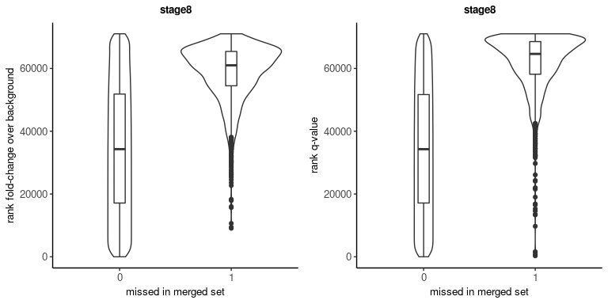

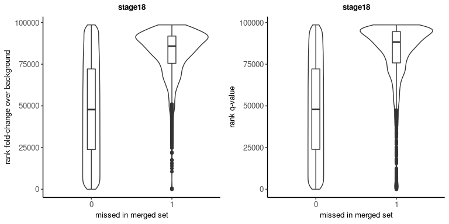

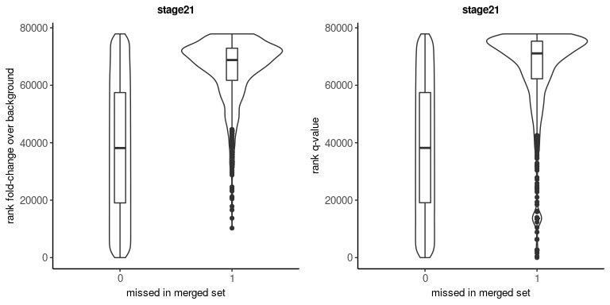

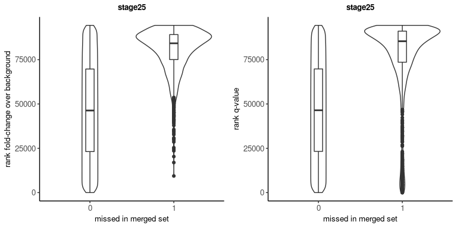

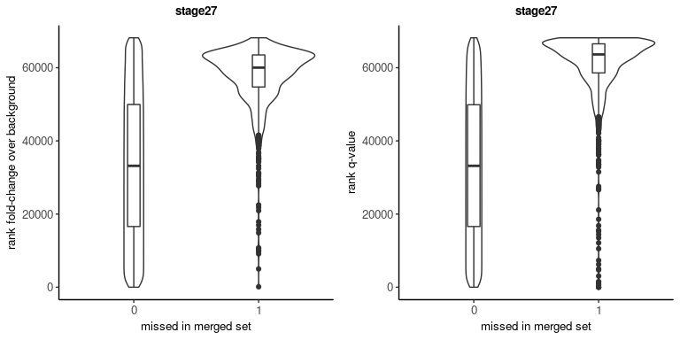

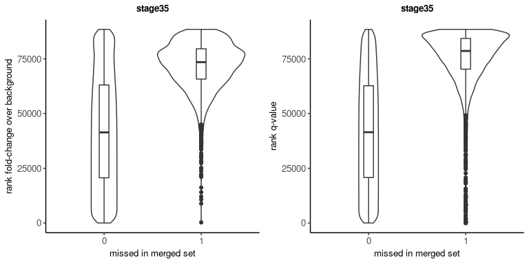

```r
for(s in paste0("stage",c(8,18,21,25,27,35))){
  df <- data.frame(peak=names(stageSets[[s]]), fc=stageSets[[s]]$fc, qval=stageSets[[s]]$qval, private=ifelse(names(stageSets[[s]]) %in% names(stageSets[[s]][stageSets[[s]] %outside% peakSet]), 1, 0))

  plots <- list()
  df <- df[order(df$fc, decreasing = TRUE),]
  plots[[1]] <- ggplot(df, aes(as.factor(private), 1:nrow(df))) + geom_violin() + geom_boxplot(width=0.1) + xlab("missed in merged set") + ylab("rank fold-change over background") + th + ggtitle(s)
  df <- df[order(df$qval, decreasing = TRUE),]
  plots[[2]] <- ggplot(df, aes(as.factor(private), 1:nrow(df))) + geom_violin() + geom_boxplot(width=0.1) + xlab("missed in merged set") + ylab("rank q-value") + th + ggtitle(s)
  multiplot(plotlist = plots, cols=2)
}
```

Thus, the majority of the peaks called only on a per-stage basis seem to be low-confidence peak calls. But there are still some with large fold-changes and small q-values that could be true peaks.

The few peaks with large fold-changes that actually look like peaks when plotting the data are almost always close to blacklisted regions.

```r
stage8 <- stage8[order(stage8$fc, decreasing = TRUE)]
stage8$blacklist <- mcols(distanceToNearest(stage8, blacklist))
stage18 <- stage18[order(stage18$fc, decreasing = TRUE)]
stage18$blacklist <- mcols(distanceToNearest(stage18, blacklist))
stage21 <- stage21[order(stage21$fc, decreasing = TRUE)]
stage21$blacklist <- mcols(distanceToNearest(stage21, blacklist))
stage25 <- stage25[order(stage25$fc, decreasing = TRUE)]
stage25$blacklist <- mcols(distanceToNearest(stage25, blacklist))
stage27 <- stage27[order(stage27$fc, decreasing = TRUE)]
stage27$blacklist <- mcols(distanceToNearest(stage27, blacklist))
stage35 <- stage35[order(stage35$fc, decreasing = TRUE)]
stage35$blacklist <- mcols(distanceToNearest(stage35, blacklist))

# median(stage35[1:10]$fc)
# median(stage35[1:10]$blacklist$distance)
#
# median(stage35[1001:1010]$fc)
# median(stage35[1001:1010]$blacklist$distance)
```

Given the larger number of samples used to call peaks in the merged set, the peaks tend to be a bit wider. Thus, in some cases, the peaks overlap blacklisted regions in the merged set whereas it misses it in the per-stage calls.

```r
## tracks
bw.norm <- readRDS("/user01/group_folders/Personal/Ximena/SOMITES/ATACseq/DATAanalysis/insertionCounts_100bpWindows_bigWigs_NORM.Rds")

samples <- meta[meta$stage==18,]$sample
toPlot <- resize(stage18, width(stage18)+10000, fix="center")
toPlot <- toPlot[order(toPlot$fc, decreasing = TRUE)]

i=1
par(mfrow=c(10,1), mar=c(1,2,1,1))
for(sample in samples){
  cov <- as.numeric(bw.norm[[sample]][[seqnames(toPlot[i])]][ranges(toPlot[i])])
  barplot(cov, width = 1, space=0, las=2)
  abline(v=c(5000, length(cov)-5000), lty=2)
}
i <- i+1
```

#### Union of stage-specifci calls

An alternative way to define a peakset would be to take the union of the peaks called from each stage.

```r
un <- union(stageSets[["stage8"]], stageSets[["stage18"]])
un <- union(un, stageSets[["stage21"]])
un <- union(un, stageSets[["stage25"]])
un <- union(un, stageSets[["stage27"]])
un <- union(un, stageSets[["stage35"]])
```

This would result in 133671 peaks, compared to the 131743 peaks called in the merged set from all 50 samples. Despite the similar numbers, the overlap is not as perfect

```r
df <- data.frame(setSize=length(un), overlap=length(unique(subjectHits(findOverlaps(peakSet, un)))))
df <- rbind(df, data.frame(setSize=length(peakSet), overlap=length(unique(queryHits(findOverlaps(peakSet, un))))))
row.names(df) <- c("union", "merged")
df$private <- df$setSize-df$overlap
df
```

```
##        setSize overlap private
## union   133671  117561   16110
## merged  131743  112082   19661
```

Again, they tend to have small fold-changes, which supports them being called only when the depth is increased by using all 50 samples. Many also have big FDRs, but not all.

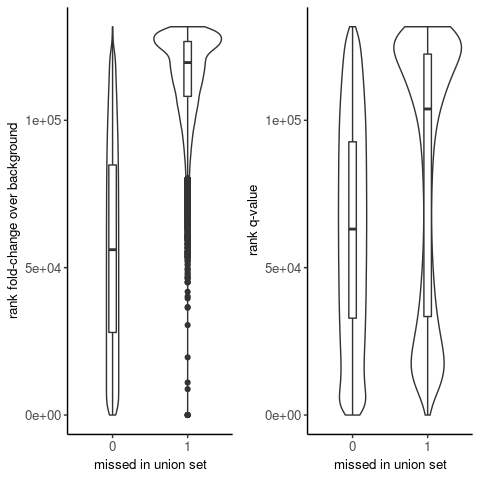

```r
peakSet$private <- 1
peakSet$private[unique(queryHits(findOverlaps(peakSet, un)))] <- 0

df <- data.frame(fc=peakSet$fc, qval=peakSet$fdr, private=peakSet$private)

plots <- list()
df <- df[order(df$fc, decreasing = TRUE),]
plots[[1]] <- ggplot(df, aes(as.factor(private), 1:nrow(df))) + geom_violin() + geom_boxplot(width=0.1) + xlab("missed in union set") + ylab("rank fold-change over background") + th
df <- df[order(df$qval, decreasing = TRUE),]
plots[[2]] <- ggplot(df, aes(as.factor(private), 1:nrow(df))) + geom_violin() + geom_boxplot(width=0.1) + xlab("missed in union set") + ylab("rank q-value") + th
multiplot(plotlist = plots, cols=2)
```

Overall, it looks like the gained peaks are generally low abundance on a per-sample basis and become significant when all samples are used, but fail to pass the noise threshold with fewer samples. A few of the peaks with large fold-changes are very sharp and it is unclear why they don’t get called on a per-stage basis. They might be flagged as artefacts?

```r
samples <- meta[meta$stage==8,]$sample
toPlot <- resize(peakSet[peakSet$private==1,], width(peakSet[peakSet$private==1,])+10000, fix="center")
toPlot <- toPlot[order(toPlot$fc, decreasing = TRUE)]

i=1
par(mfrow=c(10,1), mar=c(1,2,1,1))
for(sample in samples){
  cov <- as.numeric(bw.norm[[sample]][[seqnames(toPlot[i])]][ranges(toPlot[i])])
  barplot(cov, width = 1, space=0, las=2)
  abline(v=c(5000, length(cov)-5000), lty=2)
}
i <- i+1
```

Overall, calling peaks using all samples together seems to be a good approach, that protects against stage-specific false-positives. We might get a few false positives also, but at least these won’t be related to the stages, so shouldn’t affect the differential accessibility analysis too much.

Most of the peaks gained through increased depth are filtered out before testing due to insufficient data on a per-sample basis.